# Estudio Viviendas Ciudad Melbourne

### Sintesis resultados

```r
resultados_reg <- resamples(
                            list(
                                 GLM = reg_mod_glm, CART = reg_mod_cart,
                                 KNN = reg_mod_knn, RED_NEURONAL = reg_mod_mlp,
                                 SVM = reg_mod_svm,
                                 RF = reg_mod_rf,
                                 GBM = reg_mod_gbm, BAG = reg_mod_bag,
                                 XGBoost = reg_mod_xgb
                                )
                            )

summary(resultados_reg)
```

```
##
## Call:
## summary.resamples(object = resultados_reg)
##
## Models: GLM, CART, KNN, RED_NEURONAL, SVM, RF, GBM, BAG, XGBoost
## Number of resamples: 30
##
## MAE
##                   Min.   1st Qu.    Median      Mean   3rd Qu.      Max. NA's
## GLM          0.2493085 0.2573292 0.2646360 0.2627728 0.2674188 0.2770897    0
## CART         0.2398823 0.2474856 0.2522594 0.2513470 0.2550440 0.2616647    0
## KNN          0.1713259 0.1776606 0.1804749 0.1806148 0.1840701 0.1901750    0
## RED_NEURONAL 0.2237281 0.2960531 0.3109805 0.3313699 0.3721138 0.5030543    0
## SVM          0.1550739 0.1607244 0.1635396 0.1636682 0.1669610 0.1741495    0
## RF           0.1399449 0.1457007 0.1472664 0.1483074 0.1513222 0.1576031    0
## GBM          0.1398672 0.1451515 0.1472010 0.1469650 0.1491320 0.1532880    0
## BAG          0.2354917 0.2424755 0.2480215 0.2467395 0.2506333 0.2568808    0
## XGBoost      0.1487873 0.1550248 0.1573013 0.1573822 0.1593646 0.1680750    0
##
## RMSE
##                   Min.   1st Qu.    Median      Mean   3rd Qu.      Max. NA's
## GLM          0.3166011 0.3263576 0.3340616 0.3332766 0.3383574 0.3480858    0
## CART         0.3100114 0.3175045 0.3250037 0.3238525 0.3285383 0.3393949    0
## KNN          0.2315250 0.2372984 0.2430122 0.2436365 0.2503179 0.2610007    0
## RED_NEURONAL 0.2855078 0.3796954 0.3958486 0.4281487 0.4654323 0.6076430    0
## SVM          0.2088963 0.2174532 0.2234866 0.2242749 0.2300940 0.2438158    0
## RF           0.1875669 0.1978372 0.2015169 0.2031063 0.2080847 0.2260779    0
## GBM          0.1846130 0.1950378 0.1989587 0.1992169 0.2020464 0.2179989    0
## BAG          0.3053365 0.3115456 0.3197555 0.3186184 0.3232629 0.3354071    0
## XGBoost      0.1966049 0.2064177 0.2106180 0.2114020 0.2153237 0.2321330    0
##
## Rsquared
##                   Min.   1st Qu.    Median      Mean   3rd Qu.      Max. NA's
## GLM          0.5560085 0.5844027 0.5986492 0.5966930 0.6072753 0.6344622    0
## CART         0.5700694 0.6113578 0.6193877 0.6191218 0.6307388 0.6536824    0
## KNN          0.7509779 0.7784158 0.7837921 0.7845603 0.7943212 0.8094199    0
## RED_NEURONAL 0.1312401 0.4377702 0.4861958 0.5007836 0.6097164 0.6998185    0
## SVM          0.7648419 0.8133699 0.8179368 0.8172865 0.8287385 0.8392836    0
## RF           0.8064648 0.8436299 0.8498969 0.8501587 0.8591389 0.8764144    0
## GBM          0.8171272 0.8517425 0.8567256 0.8558618 0.8640207 0.8714874    0
## BAG          0.5863285 0.6227162 0.6304828 0.6314902 0.6451894 0.6644586    0
## XGBoost      0.7999916 0.8325233 0.8384506 0.8376886 0.8474665 0.8548802    0
```

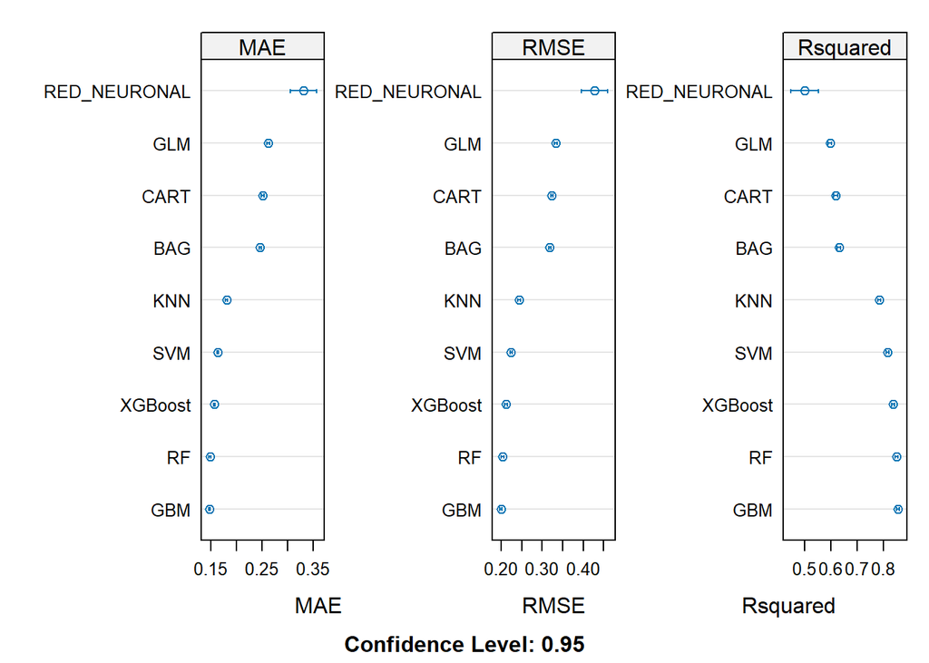

```r
dotplot(resultados_reg, scales = list(relation = "free"))
```

```r
diferencias_reg <- diff(resultados_reg)

summary(diferencias_reg)
```

```
##
## Call:
## summary.diff.resamples(object = diferencias_reg)
##
## p-value adjustment: bonferroni
## Upper diagonal: estimates of the difference
## Lower diagonal: p-value for H0: difference = 0
##
## MAE
##              GLM       CART      KNN       RED_NEURONAL SVM       RF
## GLM                     0.011426  0.082158 -0.068597     0.099105  0.114465
## CART         2.668e-09            0.070732 -0.080023     0.087679  0.103040
## KNN          < 2.2e-16 < 2.2e-16           -0.150755     0.016947  0.032307
## RED_NEURONAL 0.0001598 1.174e-05 2.695e-11               0.167702  0.183062
## SVM          < 2.2e-16 < 2.2e-16 < 2.2e-16 1.861e-12               0.015361
## RF           < 2.2e-16 < 2.2e-16 < 2.2e-16 1.715e-13    2.313e-11
## GBM          < 2.2e-16 < 2.2e-16 < 2.2e-16 1.785e-13    < 2.2e-16 1.0000000
## BAG          2.240e-12 < 2.2e-16 < 2.2e-16 4.239e-06    < 2.2e-16 < 2.2e-16
## XGBoost      < 2.2e-16 < 2.2e-16 < 2.2e-16 5.457e-13    6.641e-09 4.760e-08
##              GBM       BAG       XGBoost
## GLM           0.115808  0.016033  0.105391
## CART          0.104382  0.004607  0.093965
## KNN           0.033650 -0.066125  0.023233
## RED_NEURONAL  0.184405  0.084630  0.173988
## SVM           0.016703 -0.083071  0.006286
## RF            0.001342 -0.098432 -0.009075
## GBM                    -0.099774 -0.010417
## BAG          < 2.2e-16            0.089357
## XGBoost      < 2.2e-16 < 2.2e-16
##
## RMSE
##              GLM       CART      KNN       RED_NEURONAL SVM       RF
## GLM                     0.009424  0.089640 -0.094872     0.109002  0.130170
## CART         1.775e-08            0.080216 -0.104296     0.099578  0.120746
## KNN          < 2.2e-16 < 2.2e-16           -0.184512     0.019362  0.040530
## RED_NEURONAL 4.967e-05 9.904e-06 7.930e-11               0.203874  0.225042
## SVM          < 2.2e-16 < 2.2e-16 < 2.2e-16 8.017e-12               0.021169
## RF           < 2.2e-16 < 2.2e-16 8.243e-15 3.897e-13    8.458e-08
## GBM          < 2.2e-16 < 2.2e-16 < 2.2e-16 3.671e-13    < 2.2e-16 1.00000
## BAG          6.767e-13 < 2.2e-16 < 2.2e-16 3.997e-06    < 2.2e-16 < 2.2e-16
```

[output cut: 18 more lines]

```
## SVM          < 2.2e-16 < 2.2e-16 < 2.2e-16 1.168e-11              -0.032872
## RF           < 2.2e-16 < 2.2e-16 7.276e-14 1.629e-12    1.461e-06
## GBM          < 2.2e-16 < 2.2e-16 < 2.2e-16 5.502e-13    < 2.2e-16 1.0000000
## BAG          4.735e-13 < 2.2e-16 < 2.2e-16 0.0005234    < 2.2e-16 < 2.2e-16
## XGBoost      < 2.2e-16 < 2.2e-16 < 2.2e-16 1.931e-12    9.854e-14 0.1465847
##              GBM       BAG       XGBoost
## GLM          -0.259169 -0.034797 -0.240996
## CART         -0.236740 -0.012368 -0.218567
## KNN          -0.071301  0.153070 -0.053128
## RED_NEURONAL -0.355078 -0.130707 -0.336905
## SVM          -0.038575  0.185796 -0.020402
## RF           -0.005703  0.218669  0.012470
## GBM                     0.224372  0.018173
## BAG          < 2.2e-16           -0.206198
## XGBoost      < 2.2e-16 < 2.2e-16
```

Se ha mantenido constante el numero de resamples para asegurar generalizabilidad y para evitar el sobreajuste. En la representación gráfica comparada el mejor modelo es el GBM, mientras que el peor es el RNN. Es posible que el rendimiento del RNN se vea afectado por una de estas causas: insuficiente cantidad de datos, falta de regularización, o técnicas de optimización que no se han investigado. Los resultados obtenidos por H2O (post transformaciones) también corroboran esta conclusión.

Más en general, se aprecia que los mejores modelos y parecidos en comportamiento de RMSE son los modelos de Gradient Boosting, Random Forest y Extreme Gradient Boosting sobre el conjunto de test. Sin embargo, hay que tener en cuenta que el coste computacional difiere, en orden de mayor a menor:  
- XGB  
- GBM  
- RF

Por lo tanto, a la hora de establecer el modelo por productivizar, se podría valorar usar el Random Forest.

El mejor modelo, GBM, tiene un valor de RMSE de calculado sobre el conjunto de test muy bueno, de 0.1945713. Los modelos Random Forest y Extreme Gradient Boosting tienen variables importantes muy parecidas. Entre ellas:  
- Las variables creadas con agrupación (fe_dist, fe_tothab)  
- La latitud  
- La variable de SouthernMetropolitan

Nos encontramos con unos clasificadores con un buen nivel de precisión. En caso de disponer de más tiempo se podrían haber hecho una mejor selección de los hiperparametros y probar distintas combinaciones con algunos de los modelos probados en este estudio. Además se podría enriquecer la base de datos con más variables que podrían ser significativas. En contexto empresarial, la práctica de probar varios hiperparametros puede no ser eficiente y costar tiempo y recursos.

Finalmente, a posteriori, se considera oportuno eliminar las variables Latitude y Longitude, dado que se ha creado ya la variable de distancia y que teniendo la información por región, ya indicaría la importancia en la localización de la vivienda.

### Interpretabilidad de los modelos

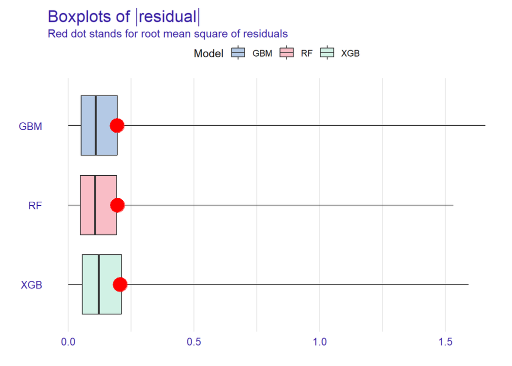

```r
load("./traintest_reg.RData")

explainer_xgb_reg <- DALEX::explain(
                                 reg_mod_xgb,
                                 label   = "XGB",
                                 data    = test_reg,
                                 y       = test_reg$Price,
                                 verbose = FALSE
                              )

explainer_gbm_reg <- DALEX::explain(
                                 reg_mod_gbm,
                                 label   = "GBM",
                                 data    = test_reg,
                                 y       = test_reg$Price,
                                 verbose = FALSE
                              )

explainer_rf_reg <- DALEX::explain(
                                 reg_mod_rf,
                                 label   = "RF",
                                 data    = test_reg,
                                 y       = test_reg$Price,
                                 verbose = FALSE
                              )



#---- Performance
mp_xgb_reg  <- model_performance(explainer_xgb_reg)
mp_gbm_reg  <- model_performance(explainer_gbm_reg)
mp_rf_reg   <- model_performance(explainer_rf_reg)

#----- Plot Comparison each group.
plot(mp_xgb_reg, mp_gbm_reg, mp_rf_reg, geom = 'boxplot')
```

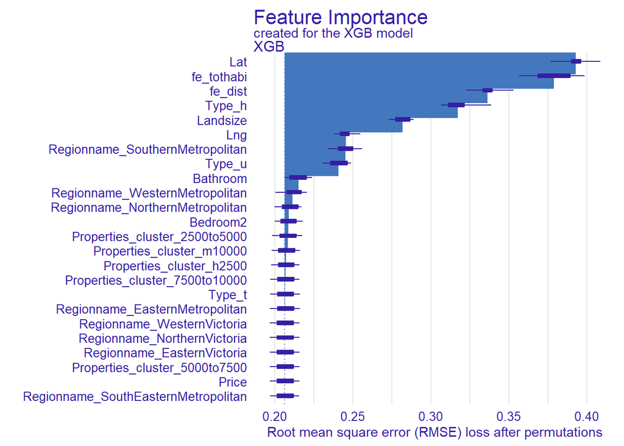

```r
vi_reg <- model_parts(explainer_xgb_reg, loss_function = loss_root_mean_square)
plot(vi_reg)
```

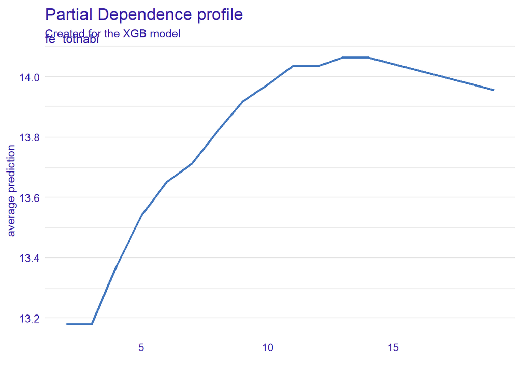

```r
pdp_reg <- model_profile(explainer_xgb_reg, variable = "fe_tothabi", type = "partial")
plot(pdp_reg)
```

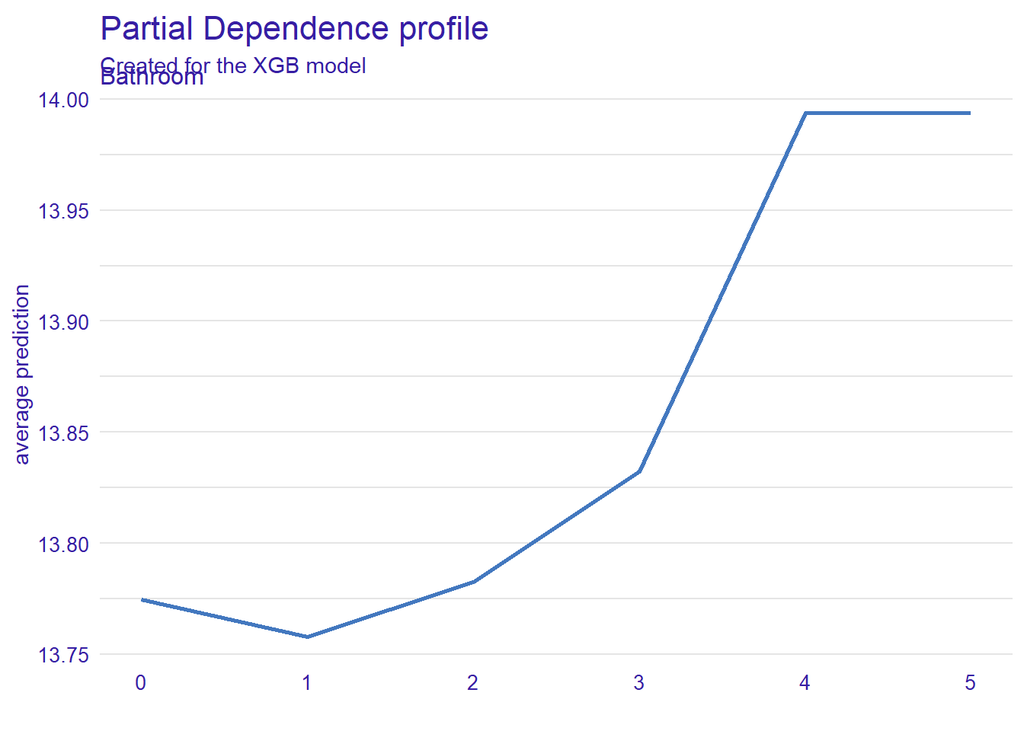

```r
pdp_reg <- model_profile(explainer_xgb_reg, variable = "Bathroom", type = "partial")
plot(pdp_reg)
```

Como se puede notar a partir de 2 baños, el precio tiende a aumentar y más significativamente a partir de 3.

```r
library(iBreakDown)
explainer_xgb_reg <- DALEX::explain(
                                 reg_mod_xgb,
                                 label   = "XGB",
                                 data    = test_reg,
                                 y       = test_reg$totalPrice,
                                 verbose = FALSE
                              )


flat_samp <- test_reg %>%
  select(-Price) %>%
  slice_sample(n = 1) %>%
  as.data.table()

bd_xgb <- break_down(explainer_xgb_reg,
                    flat_samp,
                    keep_distributions = TRUE) # distributions should be kept

#--- Takes time - ~2 mins
shap_xgb <- shap(explainer_xgb_reg, flat_samp)
```

```r
flat_samp %>% kbl(caption = "Piso seleccionado") %>% kable_minimal()
```

Piso seleccionado

| Bedroom2 | Bathroom | Landsize | Lat | Lng | fe_tothabi | fe_dist | Regionname_EasternMetropolitan | Regionname_EasternVictoria | Regionname_NorthernMetropolitan | Regionname_NorthernVictoria | Regionname_SouthEasternMetropolitan | Regionname_SouthernMetropolitan | Regionname_WesternMetropolitan | Regionname_WesternVictoria | Type_h | Type_t | Type_u | Properties_cluster_2500to5000 | Properties_cluster_5000to7500 | Properties_cluster_7500to10000 | Properties_cluster_h2500 | Properties_cluster_m10000 |
| --- | --- | --- | --- | --- | --- | --- | --- | --- | --- | --- | --- | --- | --- | --- | --- | --- | --- | --- | --- | --- | --- | --- |
| 2 | 2 | 76 | -37.7443 | 145.0015 | 6 | 149.8335 | 0 | 0 | 1 | 0 | 0 | 0 | 0 | 0 | 1 | 0 | 0 | 0 | 0 | 0 | 0 | 1 |

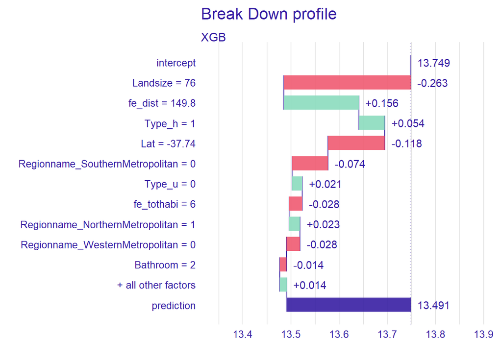

```r
#--- Plot results.
plot(bd_xgb)
```

Las demás variables tienen contribuciones más pequeñas, tanto positivas como negativas.

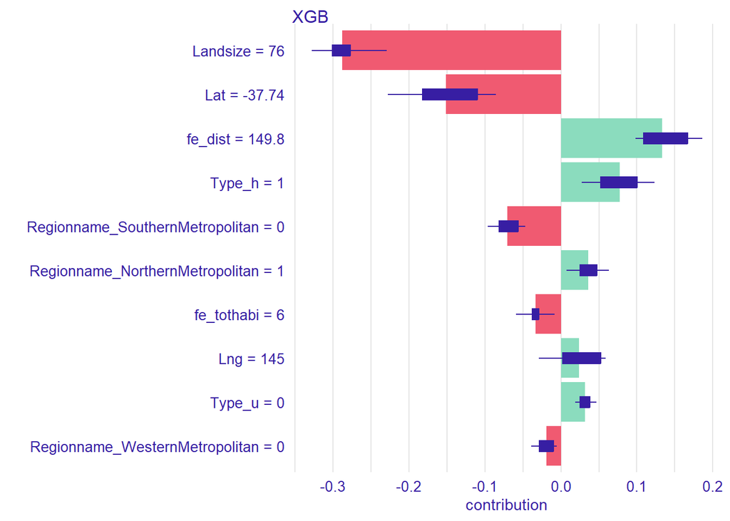

```r
plot(shap_xgb)
```

```r
#-- Description natural language
describe(bd_xgb)
```

```
## XGB predicts, that the prediction for the selected instance is 13.491 which is close to the average model prediction. For the selected instance model's prediction is lower, than for 67% of all observations.
##
## The most important variable that decrease the prediction is Landsize.
##
## Other variables are with less importance. The contribution of all other variables is -0.032.
```

```r
describe(shap_xgb)
```

```
## XGB predicts, that the prediction for the selected instance is 13.491 which is close to the average model prediction. For the selected instance model's prediction is lower, than for 67% of all observations.
##
## The most important variable that decrease the prediction is Landsize.
##
## Other variables are with less importance. The contribution of all other variables is 0.049.
```

### Productivización

Se ha productivizado el modelo usando plumber.

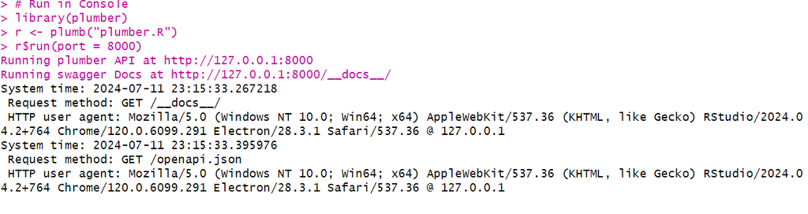

```r
knitr::include_graphics("./aplicacion/prediccionModeloPlumber.png")
```

Aquí se puede apreciar la portada de swagger donde se puede probar a insertar los valores de las variables.

[figure not shown]

```r
knitr::include_graphics("./aplicacion/prediccionModeloPortada.png")
```

A continuación, donde completar con el valor de las variables.

[figure not shown]

```r
knitr::include_graphics("./aplicacion/prediccionModelo0.png")
```

En este caso, se puede apreciar una predicción del precio, aunque está escalado. Al disponer de más tiempo, habría investigado como devolver un valor normalizado.

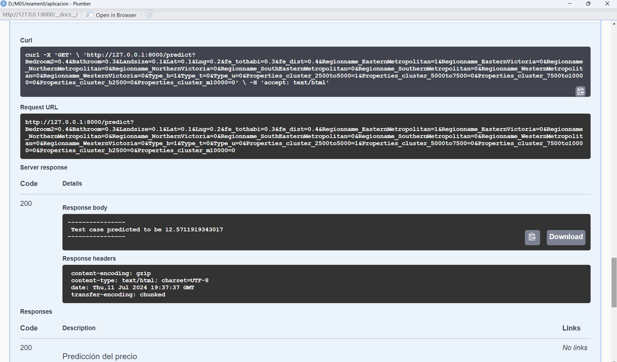

```r
knitr::include_graphics("./aplicacion/prediccionModelo.png")
```

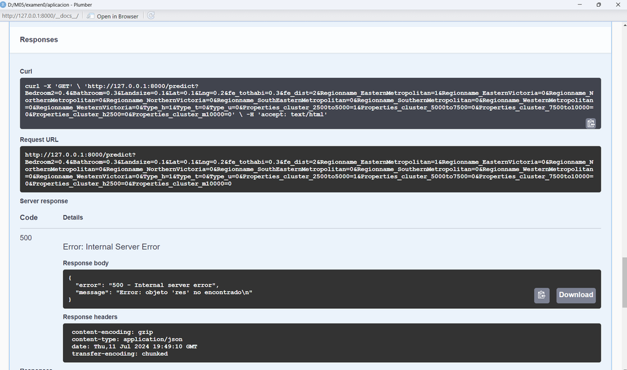

```r
knitr::include_graphics("./aplicacion/prediccionModelo2.png")
```